# DATA 624 Project 1

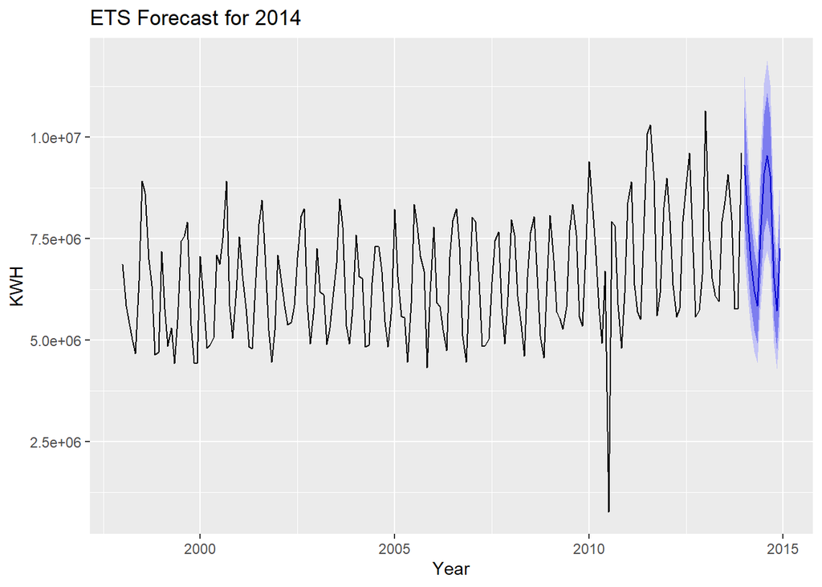

```r
# Forecast using ETS (Exponential Smoothing)
ets_model <- ets(kwh_ts)
ets_forecast <- forecast(ets_model, h = 12)
autoplot(ets_forecast) +
  ggtitle("ETS Forecast for 2014") +
  xlab("Year") + ylab("KWH")
```

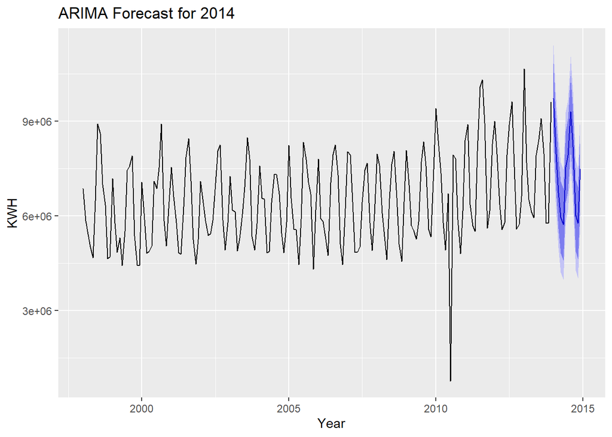

```r
# Forecast using auto.arima (optional)
arima_model <- auto.arima(kwh_ts)
arima_forecast <- forecast(arima_model, h = 12)
autoplot(arima_forecast) +
  ggtitle("ARIMA Forecast for 2014") +
  xlab("Year") + ylab("KWH")
```

```r
accuracy(ets_model)
```

```
##                    ME   RMSE      MAE      MPE     MAPE      MASE      ACF1
## Training set 61009.73 835107 503972.9 -4.39013 12.04006 0.7233624 0.1698584
```

```r
accuracy(arima_model)
```

```
##                     ME     RMSE      MAE       MPE   MAPE      MASE       ACF1
## Training set -25089.69 827254.2 493308.5 -5.511184 11.685 0.7080556 0.01283694
```

```r
lambda <- BoxCox.lambda(kwh_ts)
lambda
```

```
## [1] 0.1074118
```

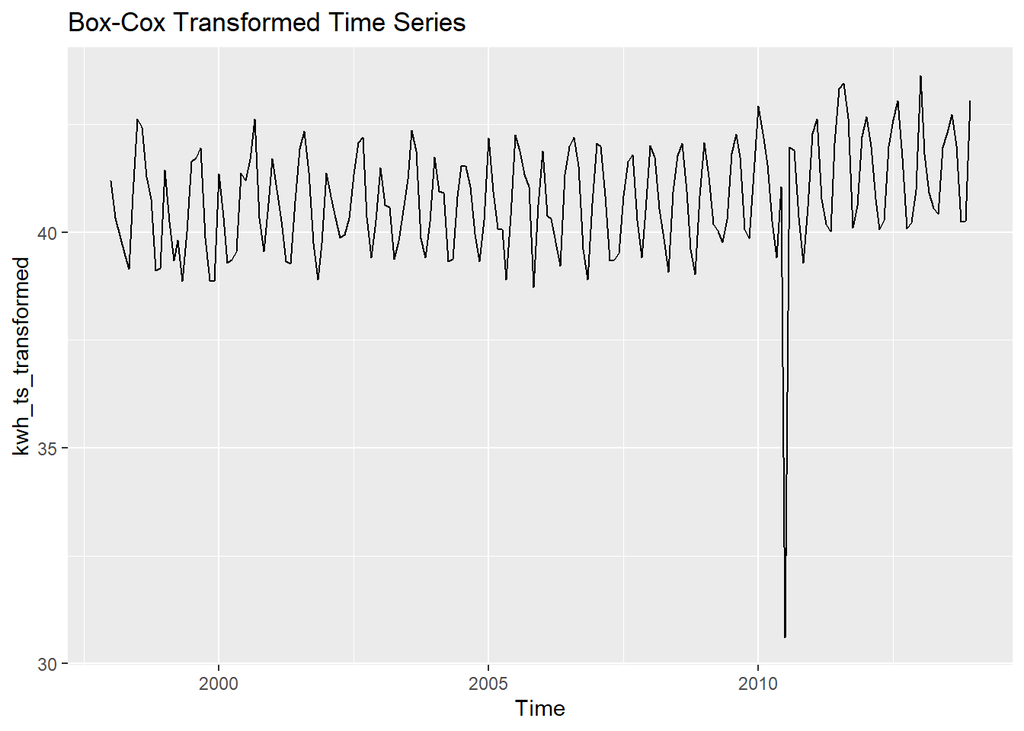

```r
kwh_ts_transformed <- BoxCox(kwh_ts, lambda)
autoplot(kwh_ts_transformed) +
  ggtitle("Box-Cox Transformed Time Series")
```

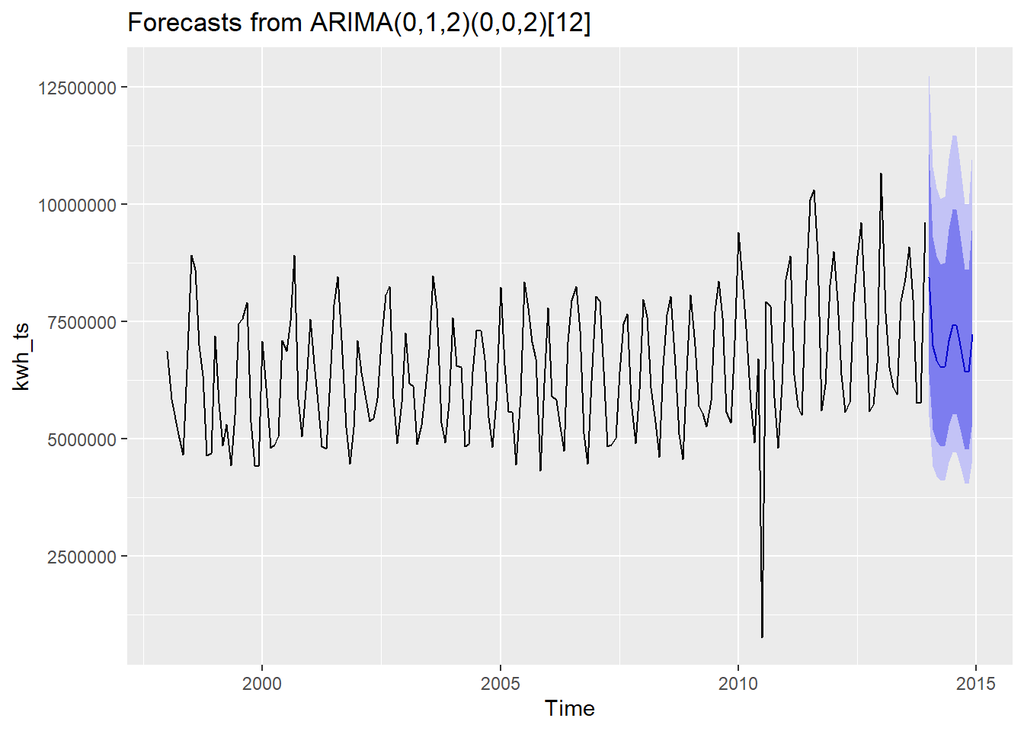

```r
ets_model2 <- ets(kwh_ts, lambda = lambda)

arima_model2 <- auto.arima(kwh_ts, lambda = lambda)

forecast_arima2 <- forecast(arima_model2, h = 12)
autoplot(forecast_arima2)
```

```r
# Create a data frame of the forecasts
forecast_df <- data.frame(
  Month = seq(as.Date("2014-01-01"), by = "month", length.out = 12),
  ETS = ets_forecast$mean,
  ARIMA = arima_forecast$mean
)

# Write to CSV
write.csv(forecast_df, "PartB_Forecast_2014.csv", row.names = FALSE)
```

## **Part C – BONUS**

Part C consists of two data sets. These are simple 2 columns sets, however they have different time stamps. Your optional assignment is to time-base sequence the data and aggregate based on hour (example of what this looks like, follows). Note for multiple recordings within an hour, take the mean. Then to determine if the data is stationary and can it be forecast. If so, provide a week forward forecast and present results via Rpubs and .rmd and the forecast in an Excel readable file.

We read the hourly water flow data from two Excel files (`Waterflow_Pipe1.xlsx` and `Waterflow_Pipe2.xlsx`), processes them to compute the average hourly flow per day, and merges them into a single dataset. It ensures the timestamps are properly formatted and handles any missing values by replacing them with zero. Finally, it combines the two pipes’ flow values into a total water flow (`Water`) at each hourly timestamp.

```r
# Load the datasets
pipe1 <- read_excel("Waterflow_Pipe1.xlsx",  col_types = c("date", "numeric"))
pipe2 <- read_excel("Waterflow_Pipe2.xlsx", col_types = c("date", "numeric"))

colnames(pipe1) <- c("DateTime", "WaterFlow")
colnames(pipe2) <- c("DateTime", "WaterFlow")



pipe1 <- pipe1 %>% mutate(Date = as.Date(DateTime), Time = hour(DateTime)+1) %>%
  group_by(Date, Time) %>%
  summarise(Water=mean(WaterFlow)) %>%
  ungroup() %>%
  mutate(DateTime=ymd_h(paste(Date,Time))) %>%
  select(DateTime,Water)
pipe2 <- pipe2 %>% mutate(Date = as.Date(DateTime), Time = hour(DateTime)+1) %>%
  group_by(Date, Time) %>%
  summarise(Water=mean(WaterFlow)) %>%
  ungroup() %>%
  mutate(DateTime=ymd_h(paste(Date,Time))) %>%
  select(DateTime,Water)
pipe2
```

```
## # A tibble: 1,000 × 2
##    DateTime            Water
##    <dttm>              <dbl>
##  1 2015-10-23 02:00:00 18.8
##  2 2015-10-23 03:00:00 43.1
##  3 2015-10-23 04:00:00 38.0
##  4 2015-10-23 05:00:00 36.1
##  5 2015-10-23 06:00:00 31.9
##  6 2015-10-23 07:00:00 28.2
##  7 2015-10-23 08:00:00  9.86
##  8 2015-10-23 09:00:00 26.7
##  9 2015-10-23 10:00:00 55.8
## 10 2015-10-23 11:00:00 54.2
## # ℹ 990 more rows
```

```r
# Convert timestamp column to datetime format
pipe1$DateTime <- ymd_hms(pipe1[[1]])
pipe2$DateTime <- ymd_hms(pipe2[[1]])




water <- full_join(pipe1, pipe2, by="DateTime", suffix=c("_1", "_2")) %>%
  mutate(Water_1=ifelse(is.na(Water_1), 0, Water_1)) %>%
  mutate(Water_2=ifelse(is.na(Water_2), 0, Water_2)) %>%
  mutate(Water = Water_1 + Water_2) %>%
  select(DateTime, Water)
```

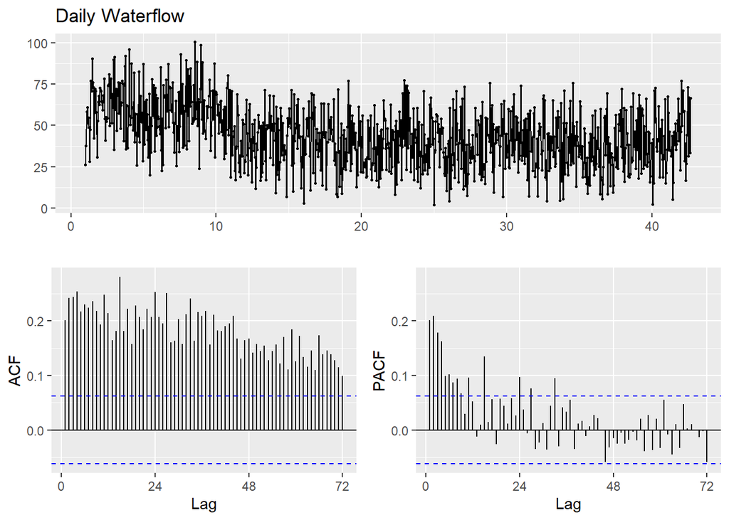

```r
# Check for gaps
water_ts <- ts(water$Water, frequency=24)
ggtsdisplay(water_ts, main="Daily Waterflow")
```

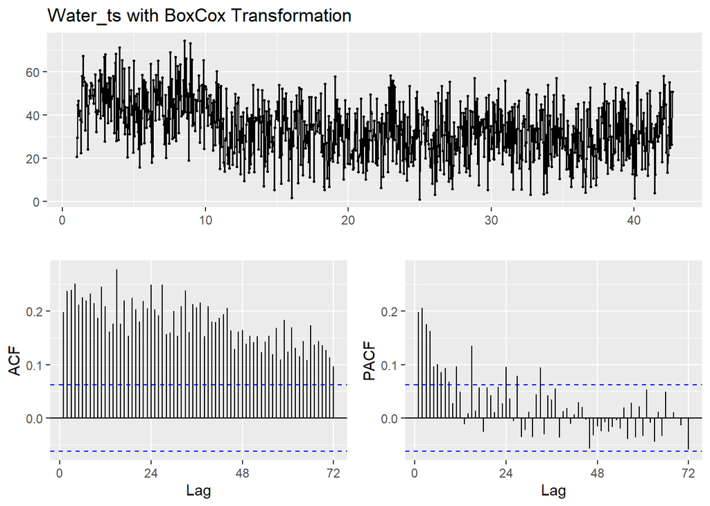

```r
water_bc <- BoxCox(water_ts, lambda = BoxCox.lambda(water_ts))
ggtsdisplay(water_bc, main="Water_ts with BoxCox Transformation")
```

```r
ndiffs(water_ts)
```

```
## [1] 1
```

```r
nsdiffs(water_ts)
```

```
## [1] 0
```

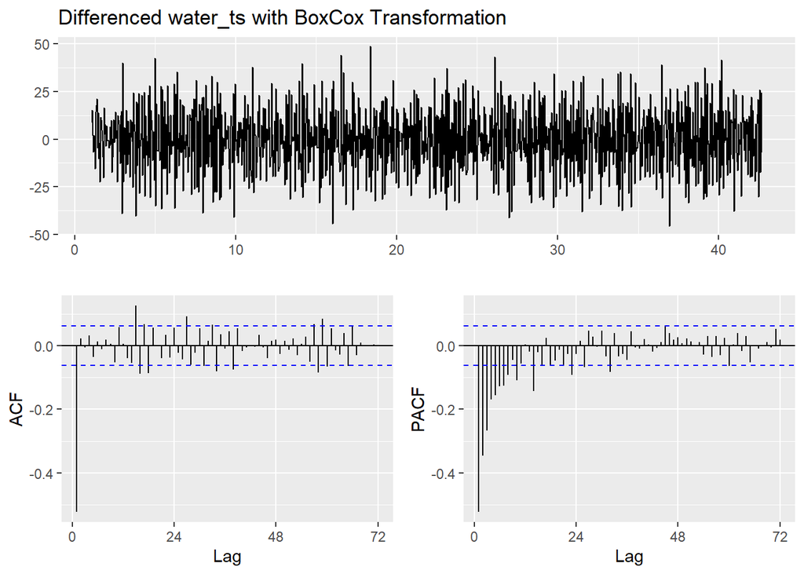

```r
ggtsdisplay(diff(water_bc), points=FALSE, main="Differenced water_ts with BoxCox Transformation")
```

```r
water_bc %>% diff() %>% ur.kpss() %>% summary()
```

```
##
## #######################
## # KPSS Unit Root Test #
## #######################
##
## Test is of type: mu with 7 lags.
##
## Value of test-statistic is: 0.0097
##
## Critical value for a significance level of:
##                 10pct  5pct 2.5pct  1pct
## critical values 0.347 0.463  0.574 0.739
```

An ARIMA(0,1,1)(0,0,1)[24] model with a Box-Cox transformation (λ = 0.9199) was fitted to the hourly water flow series. The model includes a non-seasonal moving average term (MA(1)) and a seasonal moving average term (SMA(1)) with a 24-hour seasonal period. Both coefficients are statistically significant with low standard errors. The model produced a log-likelihood of -3913.24 and an AIC of 7832.48, indicating a good fit relative to complexity. Forecast accuracy metrics show a root mean squared error (RMSE) of 16.26 and a mean absolute percentage error (MAPE) of 50.23%. The Ljung-Box test on the residuals yielded a p-value of 0.05988, suggesting no significant autocorrelation remains in the residuals at the 5% level. Overall, the model appears adequate for short-term forecasting of hourly water flow.

```r
water_arima <- Arima(water_ts, order=c(0,1,1), seasonal=c(0,0,1), lambda = BoxCox.lambda(water_ts))
summary(water_arima)
```

```
## Series: water_ts
## ARIMA(0,1,1)(0,0,1)[24]
## Box Cox transformation: lambda= 0.9199428
##
## Coefficients:
##           ma1    sma1
##       -0.9568  0.0659
## s.e.   0.0104  0.0320
##
## sigma^2 = 146.7:  log likelihood = -3913.24
## AIC=7832.48   AICc=7832.5   BIC=7847.2
##
## Training set error measures:
##                    ME    RMSE      MAE       MPE     MAPE      MASE        ACF1
## Training set 0.131665 16.2623 13.23158 -28.37285 50.22864 0.7447631 -0.03344016
```

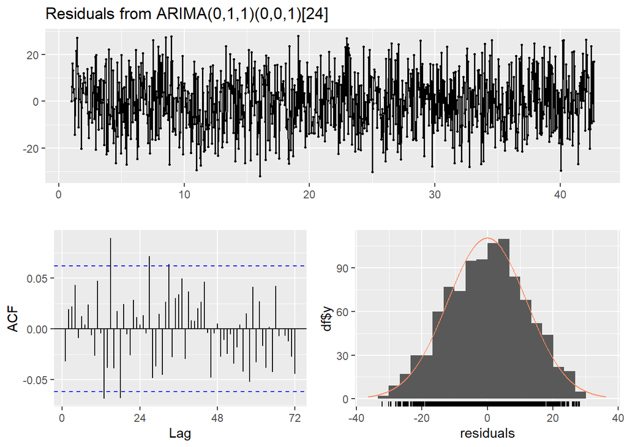

```
##
##  Ljung-Box test
##
## data:  Residuals from ARIMA(0,1,1)(0,0,1)[24]
## Q* = 61.785, df = 46, p-value = 0.05988
##
## Model df: 2.   Total lags used: 48
```

```r
checkresiduals(water_arima)
```

```r
water_auto <- auto.arima(water_ts, approximation = FALSE, lambda=BoxCox.lambda(water_ts))
summary(water_auto)
```

```
## Series: water_ts
## ARIMA(0,1,1)(0,0,1)[24]
## Box Cox transformation: lambda= 0.9199428
##
## Coefficients:
##           ma1    sma1
##       -0.9568  0.0659
## s.e.   0.0104  0.0320
##
## sigma^2 = 146.7:  log likelihood = -3913.24
## AIC=7832.48   AICc=7832.5   BIC=7847.2
##
## Training set error measures:
##                    ME    RMSE      MAE       MPE     MAPE      MASE        ACF1
## Training set 0.131665 16.2623 13.23158 -28.37285 50.22864 0.7447631 -0.03344016
```

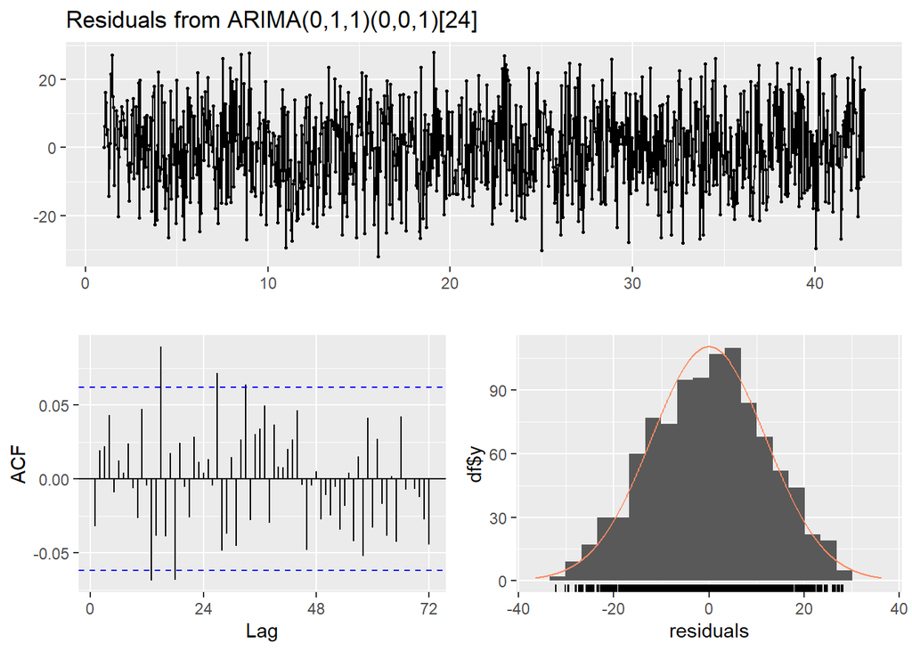

```
##
##  Ljung-Box test
##
## data:  Residuals from ARIMA(0,1,1)(0,0,1)[24]
## Q* = 61.785, df = 46, p-value = 0.05988
##
## Model df: 2.   Total lags used: 48
```

```r
checkresiduals(water_auto)
```

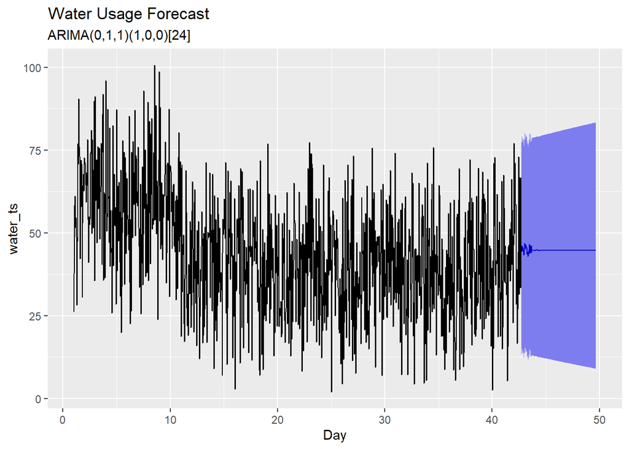

```r
water_model <- Arima(water_ts, order=c(0,1,1), seasonal=c(1,0,0), lambda = BoxCox.lambda(water_ts))
water_forecast <- forecast(water_model, h=7*24, level=95)
autoplot(water_forecast) +
  labs(title="Water Usage Forecast", subtitle = "ARIMA(0,1,1)(1,0,0)[24]", x="Day")
```

```r
library(tibble)


# Convert to data frame
forecast_df <- as.data.frame(water_forecast)

forecast_export <- forecast_df %>%
  rownames_to_column(var = "DateTime") %>%
  rename(
    Forecast = `Point Forecast`,
    Lower_95 = `Lo 95`,
    Upper_95 = `Hi 95`
  )

write_xlsx(forecast_export, "WaterFlow_ARIMA_Forecast.xlsx")
```